# Análise do dataset Forest Fires com Regressão Linear Múltipla

# 1. Contexto dos dados

O conjunto de dados “Forest Fires” contém dados e indicadores a respeito da área próxima e compreendida pelo Parque Natural de Montesinho, em Bragança, Portugal. Parte dessa área foi atingida por incêndios florestais ao logos dos três anos da amostragem dos dados (entre Janeiro de 2000 e Dezembro de 2003), e tentaremos desenvolver um modelo que relacione as variáveis do dataset com a quantidade de área atingida pelos incêndios. As variáveis que compôe o conjunto de dados são:

1. X: Coordenada x espacial dentro do Parque Montesinho (entre 1 e 9).
2. Y: Coordenada y espacial dentro do Parque Montesinho (entre 2 e 9).
3. Month: Mês do ano (de “jan” a “dec”).
4. Day: Dia da semana (de “mon” a “sun”).
5. Temp: A temperatura externa em ºC (entre 2.2 e 33.3).
6. RH: Umidade relativa externa em % (entre 15.0 e 100).
7. Wind: A velocidade do vento em km/h (entre 0.4 e 9.4).
8. Rain: A quantidade de chuva em mm/m² acumulada nos 30 minutros antes da medição (entre 0 e 6.4).
9. FFMC: Quantidade de umidade em galhos, caules e outros componentes da flora com diâmetro menor do que 1 cm (entre 18.7 e 96.20).
10. DMC: Quantidade de umidade em camadas orgânicas pouco compactadas com profundidade entre 5 e 10 centímetros (entre 1.1 e 291.3).
11. DC: Quantidade de umidade em camadas orgânicas compactadas com profundidade entre 10 e 20 centímetros (entre 7.9 e 860.6).
12. ISI: Combinação do indicador FFMC com a velocidade do vento.
13. Area: Quantidade de área queimada em hectares (entre 0 e 1090.84).

    As variáveis FFMC, DMC, DC e ISI pertencem ao FWI - Canadian Fire Weather Index. O FWI tem como objetivo avaliar o risco de incêndios florestais dados os indicadores calculados. Segue uma breve explicação do significado desses quatro indicadores:

FFMC: É interpretado como sendo o indicador do “combustível inicial” para o início dos incêndios.

DMC: É interpretado como a probabilidade da ignição de fogo por descargas atmosféricas.

DC: É interpretado como a condição de umidade a “longo prazo” da vegetação e está relacionado com os incêndios graves, que são mais difíceis de serem controlados.

ISI: É interpretado como o indicador de propagação do fogo.

Esse conjunto de dados está disponível em: https://archive.ics.uci.edu/ml/datasets/Forest+Fires.

```r
library(dplyr)
library(fields)
library(tidyverse)
library(broom)
library(corrplot)
library(ggplot2)

months <- 1:12
months_ <- c('jan', 'feb', 'mar', 'apr', 'may', 'jun', 'jul', 'aug', 'sep', 'oct', 'nov', 'dec')
names(months) <- months_

days <- 1:7
days_ <-c ('mon', 'tue', 'wed', 'thu', 'fri', 'sat', 'sun')
names(days) <- days_

dados <- read.csv("forestfires.csv")
dados$isBurned <- ifelse(dados$area == 0 , 0 , 1)
dados$lnArea <- log(dados$area + 1)

dados$month <- as.character(dados$month)
dados$month_c <- unname(months[dados$month])
dados$day <- as.character(dados$day)
dados$day_c <- unname(days[dados$day])

dados$id <- 1:nrow(dados)
dados %>%
  arrange(month_c) %>%
  mutate(idm = 1:nrow(dados)) -> dados
dados %>%
  arrange(day_c) %>%
  mutate(idd = 1:nrow(dados)) -> dados
```

# 2. Análise descritiva

O material [Applied Multivariate Analysis, Darren Homrighausen, PhD](https://darrenho.github.io/AMA/regression4example.pdf) utiliza um mecanismo para visualizar a média das áreas queimadas, conforme a localização X e Y no conjunto de dados.

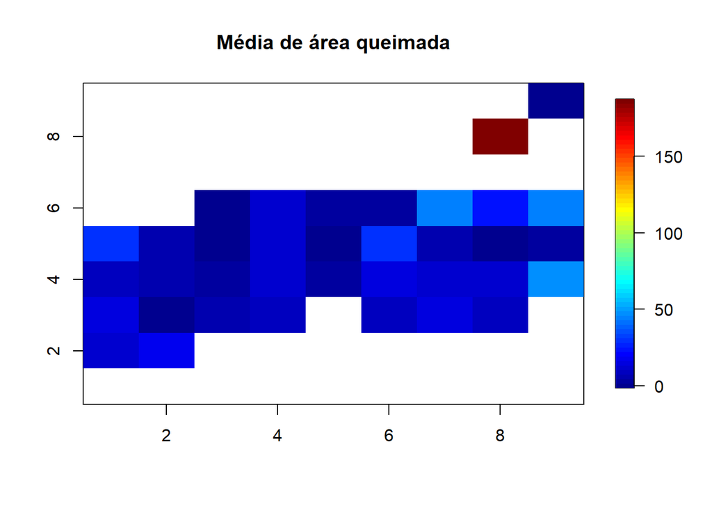

```r
x = dados$X
y = dados$Y
x.un = sort(unique(x))
y.un = 1:9
plot.resp = rep(0,length(x.un)*length(y.un))
sweep = 0
months = dados$month %>% unique()

for(i in x.un){
  for(j in y.un){
    sweep = sweep + 1
    plot.resp[sweep] = mean(dados$area[x == i & y == j])
  }
}
par(xpd=TRUE)
plot.resp.mat = matrix(plot.resp,nrow=length(x.un),ncol=length(y.un),byrow=T)
grid.list = list(x = x.un,y=1:9,z = plot.resp.mat)
image.plot(grid.list, main = "Média de área queimada")
```

Notamos que há áreas com maior média de queimada, o que indica que a localização X, Y pode ser um fator relevante na variável área queimada. É importante notar que os quadrantes que estão em branco, como por exemplo o (2, 8) não significam que não houve queimada, mas sim que são áreas que não fazem parte do conjunto de dados analisado.

# 3. Análise exploratória

```r
(prop.table(table(dados$isBurned)))
```

```
##
##         0         1
## 0.4777563 0.5222437
```

Veja que 47,77% dos registros no conjunto de dados são de áreas que não foram queimadas.

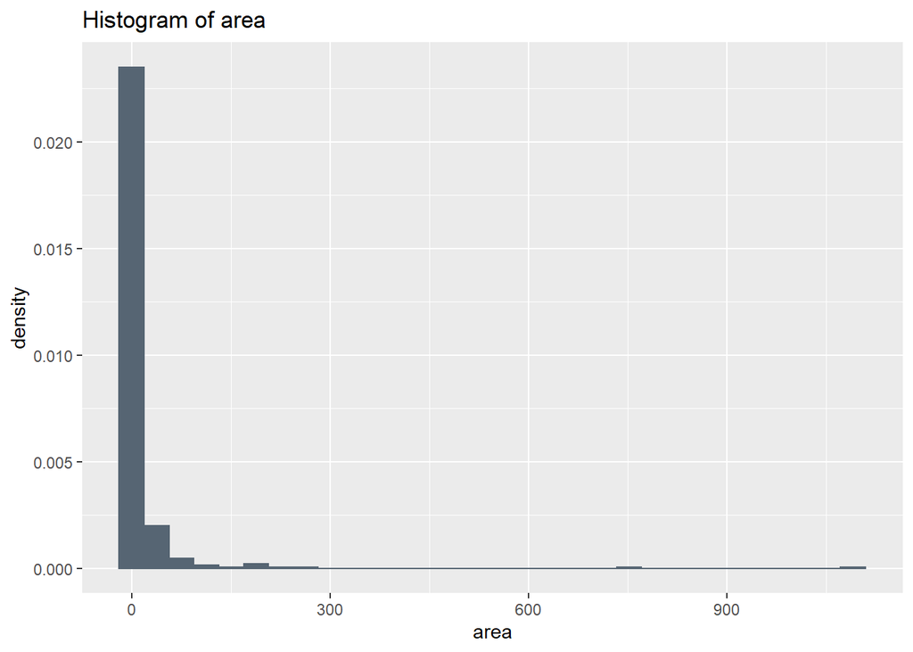

```r
dados %>%
  ggplot(., aes(x=area)) +
  geom_histogram(aes(y=..density..), colour="#566573", fill="#566573", title="a") +
  labs(title="Histogram of area")
```

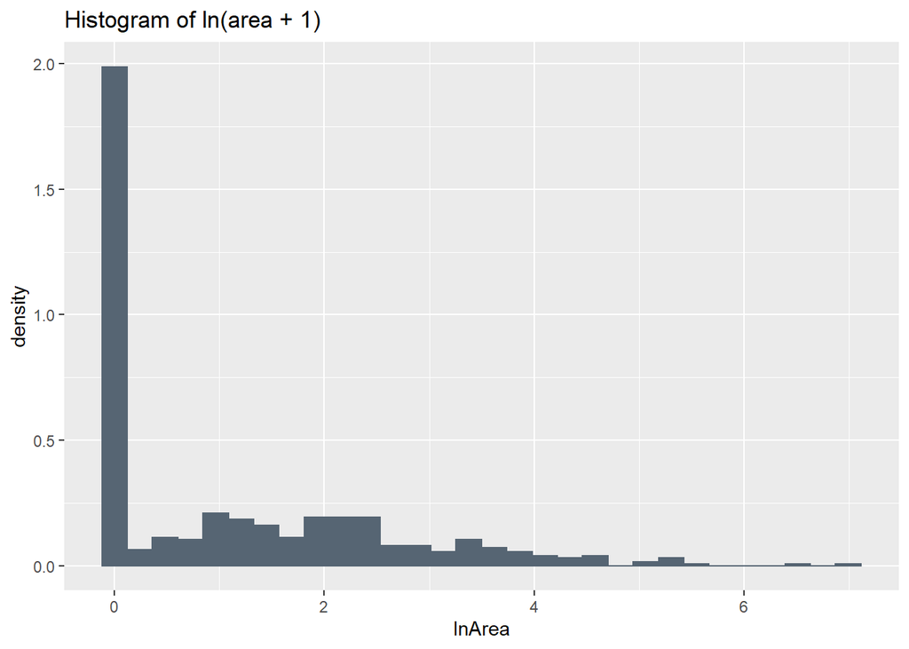

```r
dados %>%
  ggplot(., aes(x=lnArea)) +
  geom_histogram(aes(y=..density..), colour="#566573", fill="#566573")  +
  labs(title="Histogram of ln(area + 1)")
```

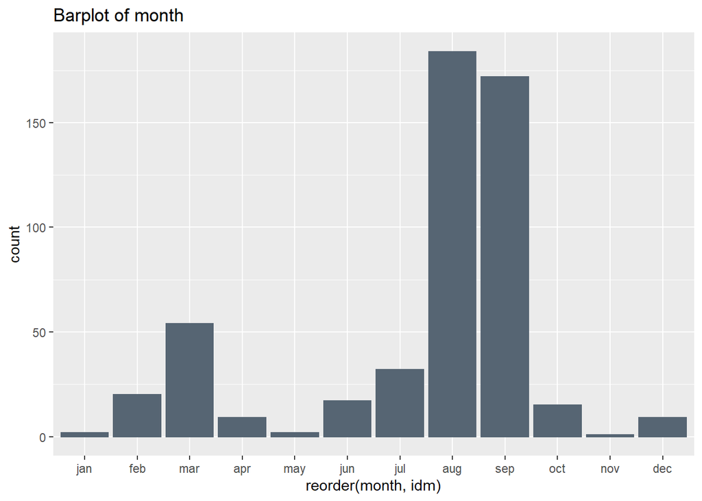

```r
dados %>%
  ggplot(., aes(x=reorder(month, idm))) +
  geom_bar(colour="#566573", fill="#566573")  +
  labs(title="Barplot of month")
```

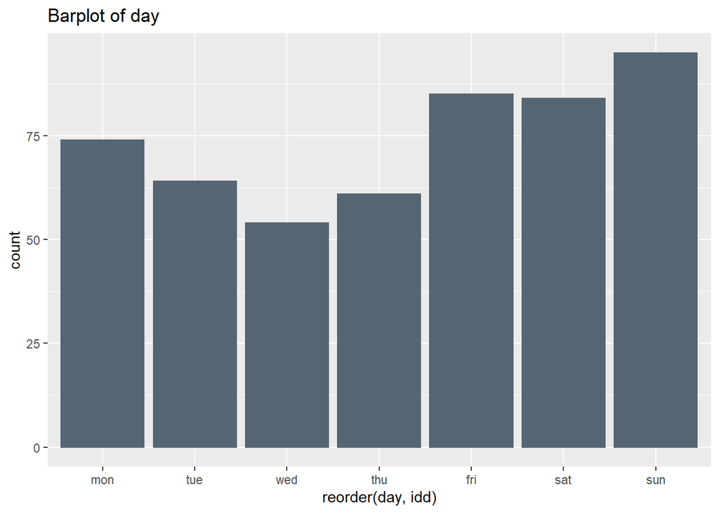

```r
dados %>%
  ggplot(., aes(x=reorder(day, idd))) +
  geom_bar(colour="#566573", fill="#566573")  +
  labs(title="Barplot of day")
```

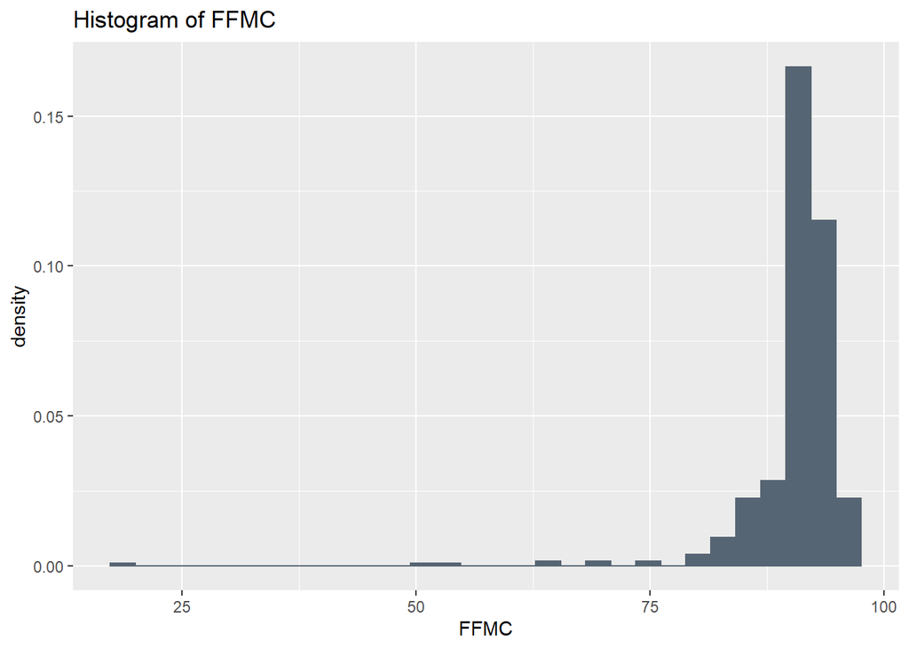

```r
dados %>%
  ggplot(., aes(x=FFMC)) +
  geom_histogram(aes(y=..density..), colour="#566573", fill="#566573")  +
  labs(title="Histogram of FFMC")
```

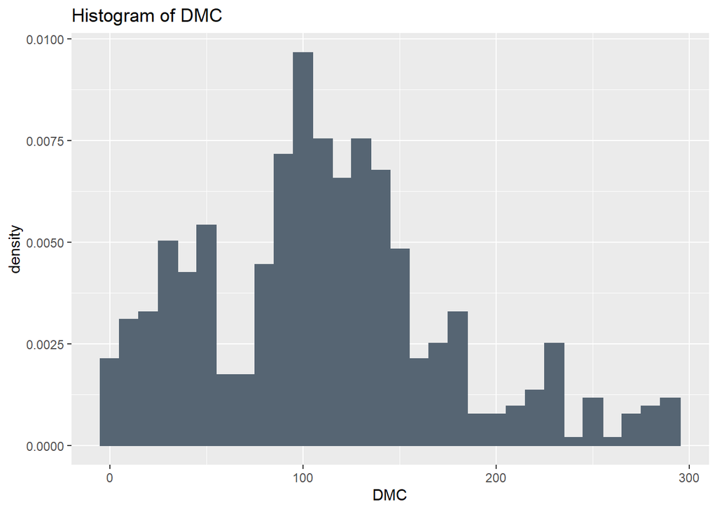

```r
dados %>%
  ggplot(., aes(x=DMC)) +
  geom_histogram(aes(y=..density..), colour="#566573", fill="#566573")  +
  labs(title="Histogram of DMC")
```

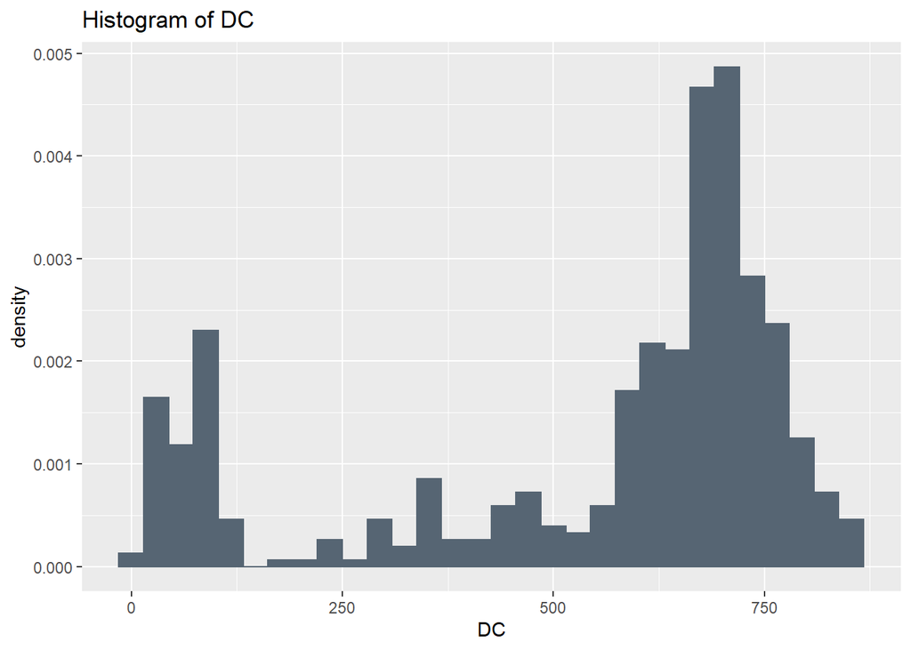

```r
dados %>%
  ggplot(., aes(x=DC)) +
  geom_histogram(aes(y=..density..), colour="#566573", fill="#566573")  +
  labs(title="Histogram of DC")
```

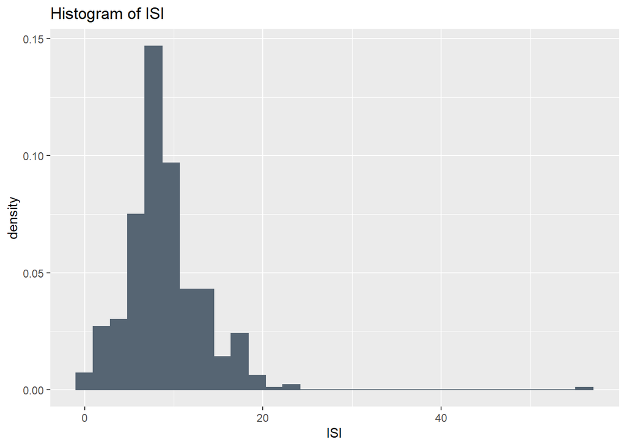

```r
dados %>%
  ggplot(., aes(x=ISI)) +
  geom_histogram(aes(y=..density..), colour="#566573", fill="#566573")  +
  labs(title="Histogram of ISI")
```

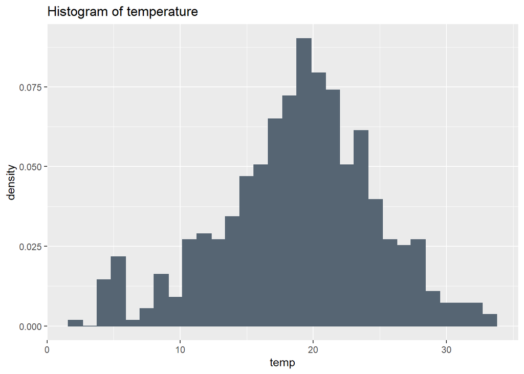

```r
dados %>%
  ggplot(., aes(x=temp)) +
  geom_histogram(aes(y=..density..), colour="#566573", fill="#566573")  +
  labs(title="Histogram of temperature")
```

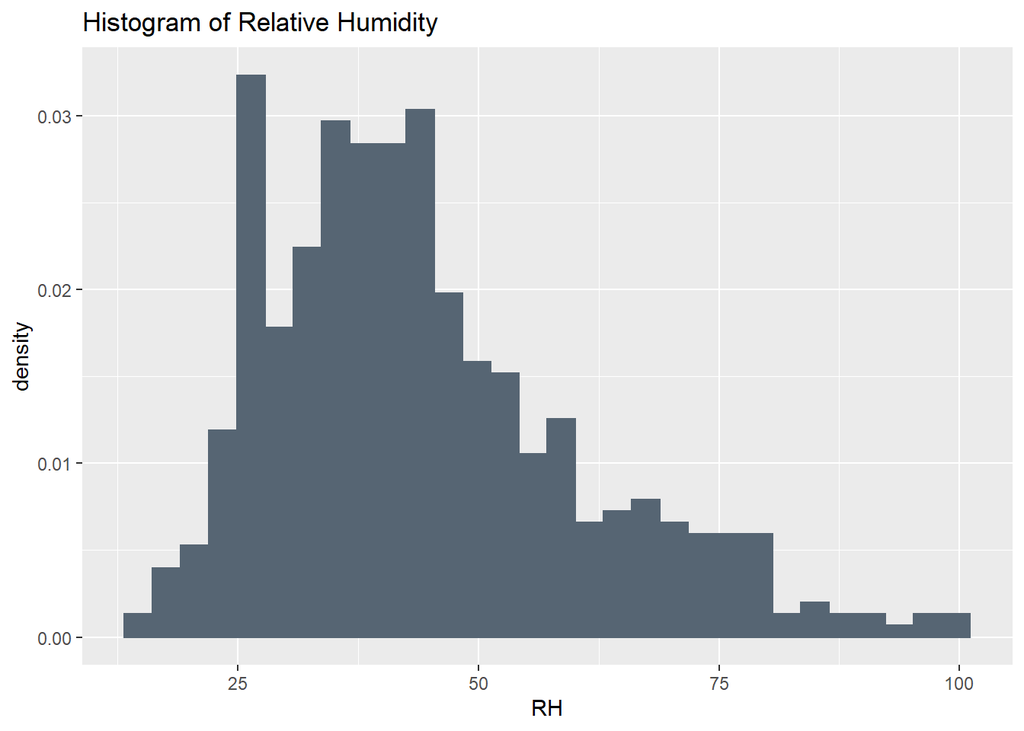

```r
dados %>%
  ggplot(., aes(x=RH)) +
  geom_histogram(aes(y=..density..), colour="#566573", fill="#566573")  +
  labs(title="Histogram of Relative Humidity")
```

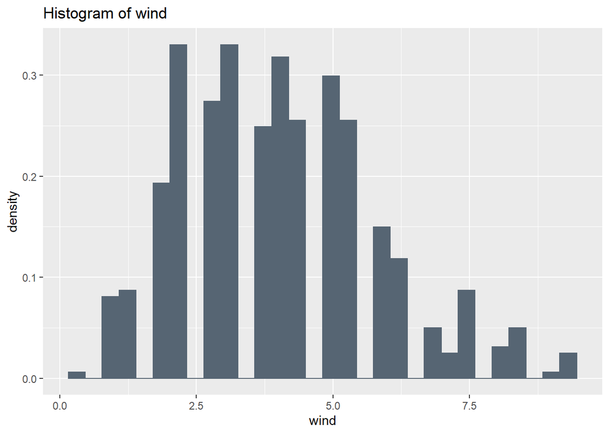

```r
dados %>%
  ggplot(., aes(x=wind)) +
  geom_histogram(aes(y=..density..), colour="#566573", fill="#566573")  +
  labs(title="Histogram of wind")
```

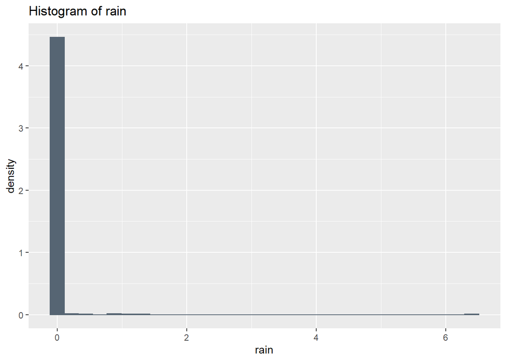

```r
dados %>%
  ggplot(., aes(x=rain)) +
  geom_histogram(aes(y=..density..), colour="#566573", fill="#566573")  +
  labs(title="Histogram of rain")
```

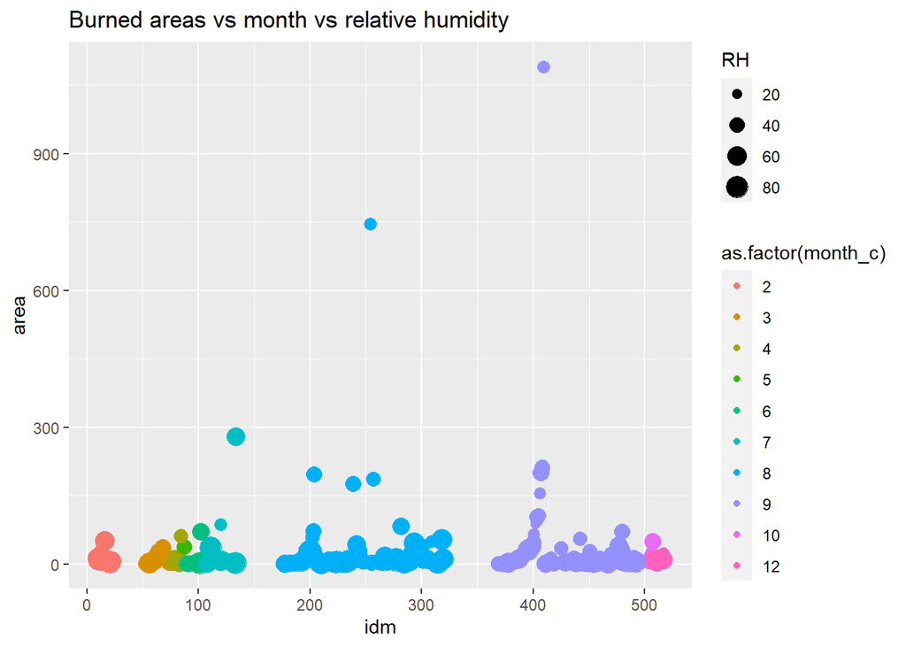

```r
dados %>%
  filter(isBurned == 1) %>%
  ggplot(., aes(x=idm, y=area)) +
  geom_point(aes(col=as.factor(month_c), size=RH)) +
  labs(title="Burned areas vs month vs relative humidity")
```

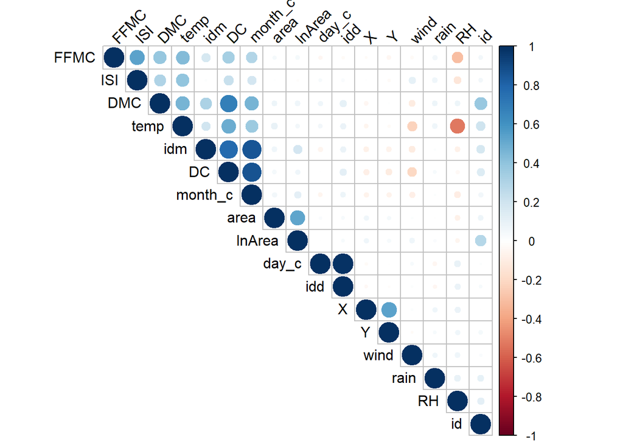

```r
dados %>%
  select(-isBurned, -month, -day) %>%
  cor() -> cor_dados
corrplot(cor_dados, type = "upper", order = "hclust",
         tl.col = "black", tl.srt = 45)
```

Pelo conjunto de dados ser tão assimétrico em relação à variável resposta, optamos por aplicar o ln(area + 1) para reduzir a variabilidade e poder ter melhores estimativas no modelo.

## Modelagem

### Forward

```r
tempdat <- dados

minimal.model = lm(lnArea ~ 1, data = tempdat)
forward.model = MASS::stepAIC(minimal.model,
                               scope = list(upper = ~  X + temp + RH + wind + DMC + month + Y + FFMC + day + ISI + rain + DC,  lower = ~1),
                              direction="forward",trace = TRUE)
```

```
## Start:  AIC=347.76
## lnArea ~ 1
##
##         Df Sum of Sq     RSS    AIC
## + DMC    1     4.551 1004.55 347.42
## + wind   1     4.526 1004.58 347.43
## + DC     1     4.444 1004.66 347.47
## <none>               1009.10 347.76
## + X      1     3.878 1005.22 347.76
## + RH     1     2.906 1006.20 348.26
## + temp   1     2.887 1006.21 348.27
## + FFMC   1     2.210 1006.89 348.62
## + Y      1     1.522 1007.58 348.98
## + rain   1     0.548 1008.55 349.47
## + ISI    1     0.108 1008.99 349.70
## + month 11    37.367  971.73 350.25
## + day    6     4.219 1004.88 357.59
##
## Step:  AIC=347.42
## lnArea ~ DMC
##
##         Df Sum of Sq     RSS    AIC
## + wind   1     5.595  998.96 346.53
## + X      1     4.306 1000.25 347.20
## <none>               1004.55 347.42
## + RH     1     3.486 1001.06 347.62
## + Y      1     1.482 1003.07 348.66
## + ISI    1     1.058 1003.49 348.87
## + month 11    39.131  965.42 348.88
## + DC     1     0.797 1003.75 349.01
## + temp   1     0.624 1003.93 349.10
## + FFMC   1     0.527 1004.02 349.15
## + rain   1     0.339 1004.21 349.24
## + day    6     4.398 1000.15 357.15
##
## Step:  AIC=346.53
## lnArea ~ DMC + wind
##
##         Df Sum of Sq    RSS    AIC
## + RH     1     4.233 994.72 346.34
```

[output cut: 24 more lines]

```
## + day    6     5.151 989.57 355.65
##
## Step:  AIC=345.74
## lnArea ~ DMC + wind + RH + X
##
##         Df Sum of Sq    RSS    AIC
## <none>               989.74 345.74
## + ISI    1     3.483 986.25 345.91
## + DC     1     1.594 988.14 346.90
## + rain   1     0.222 989.51 347.62
## + Y      1     0.053 989.68 347.71
## + FFMC   1     0.014 989.72 347.73
## + temp   1     0.010 989.73 347.73
## + month 11    37.214 952.52 347.92
## + day    6     5.065 984.67 355.08
```

```r
summary(forward.model)
```

```
##
## Call:
## lm(formula = lnArea ~ DMC + wind + RH + X, data = tempdat)
##
## Residuals:
##     Min      1Q  Median      3Q     Max
## -1.6632 -1.0845 -0.5947  0.9431  5.7042
##
## Coefficients:
##               Estimate Std. Error t value Pr(>|t|)
## (Intercept)  0.7295878  0.2684178   2.718  0.00679 **
## DMC          0.0018388  0.0009656   1.904  0.05744 .
## wind         0.0620312  0.0344587   1.800  0.07242 .
## RH          -0.0061204  0.0037875  -1.616  0.10672
## X            0.0427076  0.0265907   1.606  0.10887
## ---
## Signif. codes:  0 '***' 0.001 '**' 0.01 '*' 0.05 '.' 0.1 ' ' 1
##
## Residual standard error: 1.39 on 512 degrees of freedom
## Multiple R-squared:  0.01919,    Adjusted R-squared:  0.01153
## F-statistic: 2.504 on 4 and 512 DF,  p-value: 0.04144
```

```r
#forward.model2 = MASS::stepAIC(minimal.model,
#                               scope = list(upper = ~ temp + RH + wind + X + Y + DMC + month + FFMC + day + ISI + rain + DC,  lower = ~1),
#                              direction="forward",trace = TRUE)

# Backward Regression
```

### Backward

```r
full.model = lm(lnArea ~  X + temp + RH + wind + DMC + month + Y + FFMC + day + ISI + rain + DC, data = tempdat)
backward.model = MASS::stepAIC(full.model,
                                scope = list(upper = ~ X + temp + RH + wind + DMC + month + Y + FFMC + day + ISI + rain + DC,  lower = ~1),
                               direction="backward",trace = TRUE)
```

```
## Start:  AIC=361.86
## lnArea ~ X + temp + RH + wind + DMC + month + Y + FFMC + day +
##     ISI + rain + DC
##
##         Df Sum of Sq    RSS    AIC
## - day    6     6.063 940.23 353.21
## - RH     1     0.022 934.19 359.88
## - rain   1     0.040 934.21 359.88
## - Y      1     0.175 934.34 359.96
## - FFMC   1     0.383 934.55 360.07
## - ISI    1     1.293 935.46 360.58
## <none>               934.17 361.86
## - wind   1     4.694 938.86 362.45
## - DC     1     4.758 938.92 362.49
## - temp   1     4.987 939.15 362.62
## - X      1     4.997 939.16 362.62
## - month 11    44.035 978.20 363.68
## - DMC    1     9.455 943.62 365.07
##
## Step:  AIC=353.21
## lnArea ~ X + temp + RH + wind + DMC + month + Y + FFMC + ISI +
##     rain + DC
##
##         Df Sum of Sq    RSS    AIC
## - RH     1     0.042 940.27 351.23
## - rain   1     0.104 940.33 351.26
## - Y      1     0.213 940.44 351.32
## - FFMC   1     0.248 940.48 351.34
## - ISI    1     1.319 941.55 351.93
## <none>               940.23 353.21
## - wind   1     4.363 944.59 353.60
## - X      1     5.127 945.36 354.02
## - DC     1     5.504 945.73 354.22
## - temp   1     5.809 946.04 354.39
## - month 11    43.276 983.50 354.47
## - DMC    1     9.457 949.69 356.38
##
## Step:  AIC=351.23
## lnArea ~ X + temp + wind + DMC + month + Y + FFMC + ISI + rain +
##     DC
```

[output cut: 52 more lines]

```
## - month 11    46.709 987.57 348.60
## - DMC    1    10.916 951.78 349.52
## - temp   1    11.766 952.63 349.98
##
## Step:  AIC=344.11
## lnArea ~ X + temp + wind + DMC + month + DC
##
##         Df Sum of Sq    RSS    AIC
## <none>               941.88 344.11
## - wind   1     3.860 945.74 344.23
## - DC     1     4.958 946.84 344.83
## - X      1     5.839 947.72 345.31
## - DMC    1    10.439 952.32 347.81
## - temp   1    10.886 952.76 348.06
## - month 11    49.627 991.51 348.66
```

```r
summary(backward.model)
```

```
##
## Call:
## lm(formula = lnArea ~ X + temp + wind + DMC + month + DC, data = tempdat)
##
## Residuals:
##     Min      1Q  Median      3Q     Max
## -1.8548 -1.0223 -0.5419  0.8632  5.3110
##
## Coefficients:
##              Estimate Std. Error t value Pr(>|t|)
## (Intercept)  0.185102   0.551165   0.336  0.73713
## X            0.047093   0.026748   1.761  0.07891 .
## temp         0.034672   0.014423   2.404  0.01658 *
## wind         0.052480   0.036661   1.431  0.15292
## DMC          0.004151   0.001763   2.354  0.01896 *
## monthaug     0.320707   0.778747   0.412  0.68065
## monthdec     2.203821   0.759455   2.902  0.00387 **
## monthfeb     0.198425   0.553782   0.358  0.72026
## monthjan    -0.443735   1.087663  -0.408  0.68347
## monthjul     0.127736   0.675077   0.189  0.85000
## monthjun    -0.361830   0.627481  -0.577  0.56444
## monthmar    -0.341704   0.496272  -0.689  0.49143
## monthmay     0.751387   1.074740   0.699  0.48479
## monthnov    -0.913303   1.449364  -0.630  0.52889
## monthoct     0.864504   0.946985   0.913  0.36173
## monthsep     0.974630   0.883186   1.104  0.27032
## DC          -0.001988   0.001225  -1.622  0.10535
## ---
## Signif. codes:  0 '***' 0.001 '**' 0.01 '*' 0.05 '.' 0.1 ' ' 1
##
## Residual standard error: 1.373 on 500 degrees of freedom
## Multiple R-squared:  0.06662,    Adjusted R-squared:  0.03675
## F-statistic:  2.23 on 16 and 500 DF,  p-value: 0.00404
```

### Stepwise

```r
initial.model = lm(lnArea ~ 1, data = tempdat)
stepwise.model = MASS::stepAIC(initial.model,
                                scope = list(upper = ~   X + temp + RH + wind + DMC + month + Y + FFMC + day + ISI + rain + DC,
                                             lower = ~1),
                               direction="both",trace = TRUE)
```

```
## Start:  AIC=347.76
## lnArea ~ 1
##
##         Df Sum of Sq     RSS    AIC
## + DMC    1     4.551 1004.55 347.42
## + wind   1     4.526 1004.58 347.43
## + DC     1     4.444 1004.66 347.47
## <none>               1009.10 347.76
## + X      1     3.878 1005.22 347.76
## + RH     1     2.906 1006.20 348.26
## + temp   1     2.887 1006.21 348.27
## + FFMC   1     2.210 1006.89 348.62
## + Y      1     1.522 1007.58 348.98
## + rain   1     0.548 1008.55 349.47
## + ISI    1     0.108 1008.99 349.70
## + month 11    37.367  971.73 350.25
## + day    6     4.219 1004.88 357.59
##
## Step:  AIC=347.42
## lnArea ~ DMC
##
##         Df Sum of Sq     RSS    AIC
## + wind   1     5.595  998.96 346.53
## + X      1     4.306 1000.25 347.20
## <none>               1004.55 347.42
## + RH     1     3.486 1001.06 347.62
## - DMC    1     4.551 1009.10 347.76
## + Y      1     1.482 1003.07 348.66
## + ISI    1     1.058 1003.49 348.87
## + month 11    39.131  965.42 348.88
## + DC     1     0.797 1003.75 349.01
## + temp   1     0.624 1003.93 349.10
## + FFMC   1     0.527 1004.02 349.15
## + rain   1     0.339 1004.21 349.24
## + day    6     4.398 1000.15 357.15
##
## Step:  AIC=346.53
## lnArea ~ DMC + wind
##
##         Df Sum of Sq     RSS    AIC
```

[output cut: 34 more lines]

```
##
##         Df Sum of Sq    RSS    AIC
## <none>               989.74 345.74
## + ISI    1     3.483 986.25 345.91
## - X      1     4.987 994.72 346.34
## - RH     1     5.048 994.78 346.37
## + DC     1     1.594 988.14 346.90
## - wind   1     6.264 996.00 347.00
## - DMC    1     7.009 996.75 347.39
## + rain   1     0.222 989.51 347.62
## + Y      1     0.053 989.68 347.71
## + FFMC   1     0.014 989.72 347.73
## + temp   1     0.010 989.73 347.73
## + month 11    37.214 952.52 347.92
## + day    6     5.065 984.67 355.08
```

```r
summary(stepwise.model)
```

```
##
## Call:
## lm(formula = lnArea ~ DMC + wind + RH + X, data = tempdat)
##
## Residuals:
##     Min      1Q  Median      3Q     Max
## -1.6632 -1.0845 -0.5947  0.9431  5.7042
##
## Coefficients:
##               Estimate Std. Error t value Pr(>|t|)
## (Intercept)  0.7295878  0.2684178   2.718  0.00679 **
## DMC          0.0018388  0.0009656   1.904  0.05744 .
## wind         0.0620312  0.0344587   1.800  0.07242 .
## RH          -0.0061204  0.0037875  -1.616  0.10672
## X            0.0427076  0.0265907   1.606  0.10887
## ---
## Signif. codes:  0 '***' 0.001 '**' 0.01 '*' 0.05 '.' 0.1 ' ' 1
##
## Residual standard error: 1.39 on 512 degrees of freedom
## Multiple R-squared:  0.01919,    Adjusted R-squared:  0.01153
## F-statistic: 2.504 on 4 and 512 DF,  p-value: 0.04144
```

```r
#set.seed(157)
#id <- sample(1:nrow(tempdat), size = trunc(runif(1,.7,1)*nrow(tempdat)),replace = F)
#sampDados <- dados[id,]
#full.model = lm(lnArea ~ temp + RH + wind + X + Y + DMC + month + FFMC + day + ISI + rain + DC, data = sampDados)
#backward.model3 = MASS::stepAIC(full.model,
#scope = list(upper = ~ temp + RH + wind + X + Y + DMC + month + FFMC + day + ISI + rain + DC, lower = ~1), direction="backward",trace = TRUE)

#summary(backward.model3)
```

# 4. Análise dos resultados

A respeito das variáveis selecionadas, a que se mostrou mais relevante foi a “month”, onde percebemos uma influência forte dessa variável quando ela possui o valor “dec”, o que seriam o mês de dezembro.

Esse modelo obteve um erro residual padrão muito grande, se comparado ao intercepto encontrado, o que indica uma porcentagem de erro bastante alta.